# Problem Set 2

Author

Peng Chen

Published

October 16, 2026

**GitHub repo:** https://github.com/perry-pezza/ec522_ps2_chen

## Data

This problem set we use monthly unemployment rate data directly from FRED for the United States and four individual states (Oregon, California, Texas, and New York), the data from 1976-01-01

```r
library(tidyverse)
setwd("D:/Oregon/economics forecasting/ec522_ps2_chen")
source("ps2_script_chen.R")
head(unemp_raw)
```

```
# A tibble: 6 × 3
  symbol date       price
  <chr>  <date>     <dbl>
1 UNRATE 1976-01-01   7.9
2 UNRATE 1976-02-01   7.7
3 UNRATE 1976-03-01   7.6
4 UNRATE 1976-04-01   7.7
5 UNRATE 1976-05-01   7.4
6 UNRATE 1976-06-01   7.6
```

## Wrangling

First, we used `rename()` and `mutate()` with `case_when()` to clean the data. We created a data frame called `unemp` by renaming `price` to `unemployment_rate` and adding a new column, `region`, with readable names for the five regions (United States, Oregon, California, Texas, and New York). Then, we used `filter()`, `mutate()`, `group_by()`, `summarize()`, and `arrange()` to process and analyze the unemployment data, using the pipe operator `|>` to connect these operations. **Table 1:** Summary statistics of unemployment rates for the full sample, including the mean, minimum, and maximum.

```r
knitr::kable(unemp_summary)
```

| region | mean_rate | min_rate | max_rate |
| --- | --- | --- | --- |
| California | 7.077595 | 3.8 | 16.1 |
| New York | 6.349918 | 3.8 | 16.7 |
| Oregon | 6.664086 | 3.4 | 13.7 |
| Texas | 5.849423 | 3.4 | 12.8 |
| United States | 6.049342 | 3.4 | 14.8 |

```r
knitr::kable(unemp_recent_summary)
```

[output not shown]

**Table 3:** The largest monthly increases in unemployment rates, excluding 2020.

```r
knitr::kable(unemp_top_increases_no_covid)
```

| symbol | date | unemployment_rate | region | unemployment_rate_change |
| --- | --- | --- | --- | --- |
| TXUR | 2009-05-01 | 7.6 | Texas | 1.1 |
| ORUR | 2008-12-01 | 8.9 | Oregon | 0.7 |
| ORUR | 2008-11-01 | 8.2 | Oregon | 0.7 |
| ORUR | 2009-01-01 | 9.6 | Oregon | 0.7 |
| ORUR | 1980-03-01 | 7.4 | Oregon | 0.6 |
| UNRATE | 1980-04-01 | 6.9 | United States | 0.6 |

**Table 4:** The largest monthly decreases in unemployment rates, excluding 2020.

```r
knitr::kable(unemp_top_decreases_no_covid)
```

| symbol | date | unemployment_rate | region | unemployment_rate_change |
| --- | --- | --- | --- | --- |
| UNRATE | 1983-07-01 | 9.4 | United States | -0.7 |
| NYUR | 2021-09-01 | 6.2 | New York | -0.6 |
| ORUR | 1977-05-01 | 7.8 | Oregon | -0.5 |
| CAUR | 2021-07-01 | 7.4 | California | -0.5 |
| CAUR | 2021-09-01 | 6.5 | California | -0.5 |
| NYUR | 2021-07-01 | 7.0 | New York | -0.5 |
| UNRATE | 2010-12-01 | 9.3 | United States | -0.5 |
| UNRATE | 2014-04-01 | 6.2 | United States | -0.5 |
| UNRATE | 2021-07-01 | 5.4 | United States | -0.5 |

## Visualization

The following figures illustrate unemployment rate patterns across the five regions.

**Figure 1:** Unemployment rates over the full sample period.

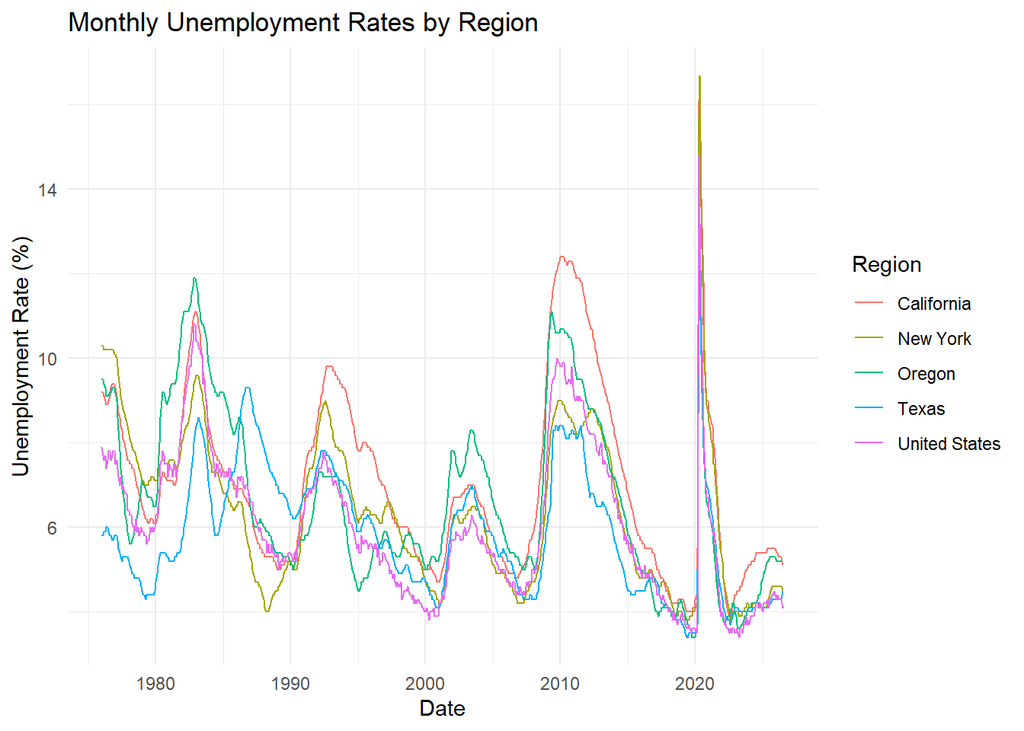

```r
ggplot(unemp, aes(x = date, y = unemployment_rate, color = region)) +
  geom_line() +
  labs(
    title = "Monthly Unemployment Rates by Region",
    x = "Date",
    y = "Unemployment Rate (%)",
    color = "Region"
  ) +
  theme_minimal()
```

**Figure 2:** Unemployment rates displayed separately for each region.

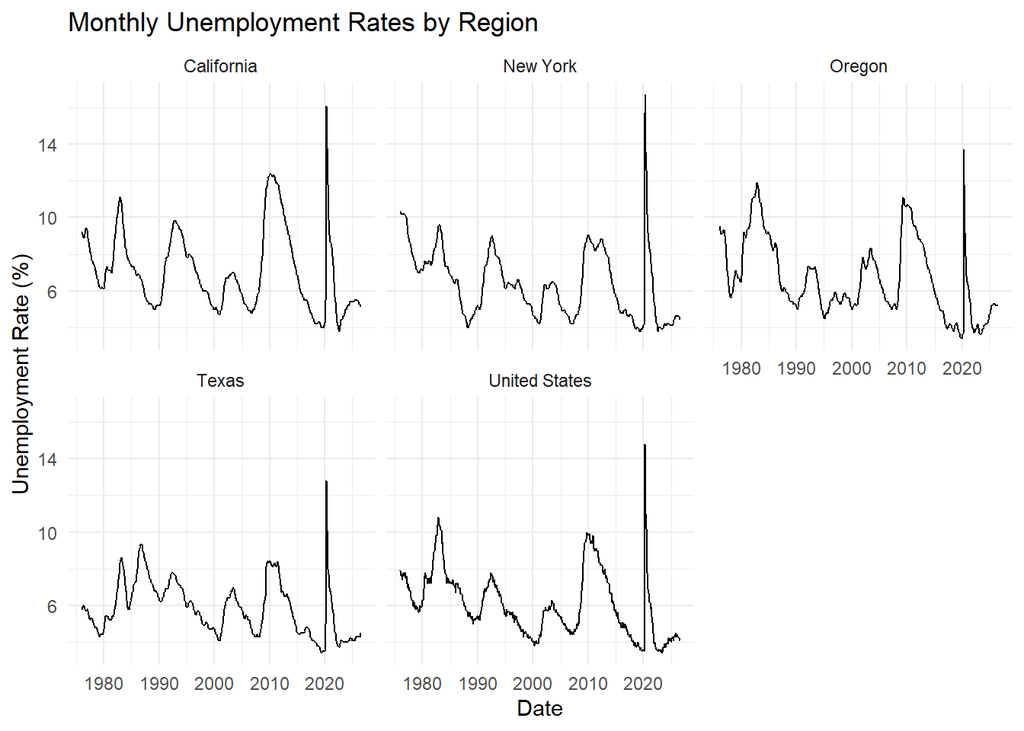

```r
ggplot(unemp, aes(x = date, y = unemployment_rate)) +
  geom_line() +
  facet_wrap(~ region) +
  labs(
    title = "Monthly Unemployment Rates by Region",
    x = "Date",
    y = "Unemployment Rate (%)"
  ) +
  theme_minimal()
```

**Figure 3:** Average unemployment rates by region.

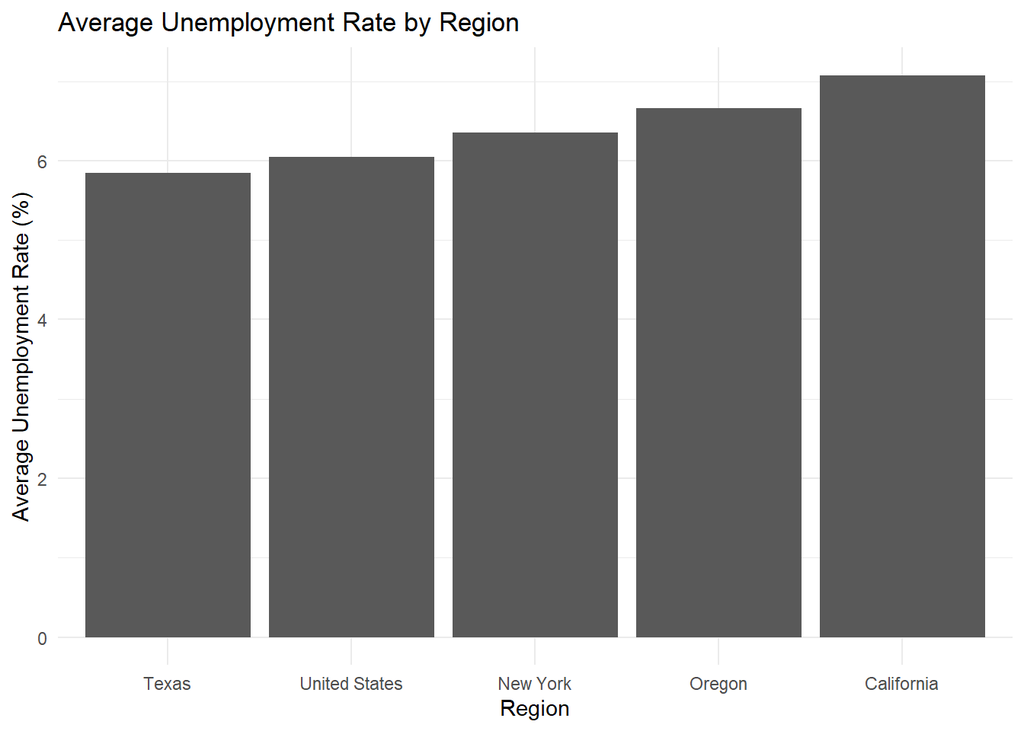

```r
ggplot(unemp_summary,
       aes(x = fct_reorder(region, mean_rate),
           y = mean_rate)) +
  geom_col() +
  labs(
    title = "Average Unemployment Rate by Region",
    x = "Region",
    y = "Average Unemployment Rate (%)"
  ) +
  theme_minimal()
```

**Figure 4:** Unemployment rates since 2015.

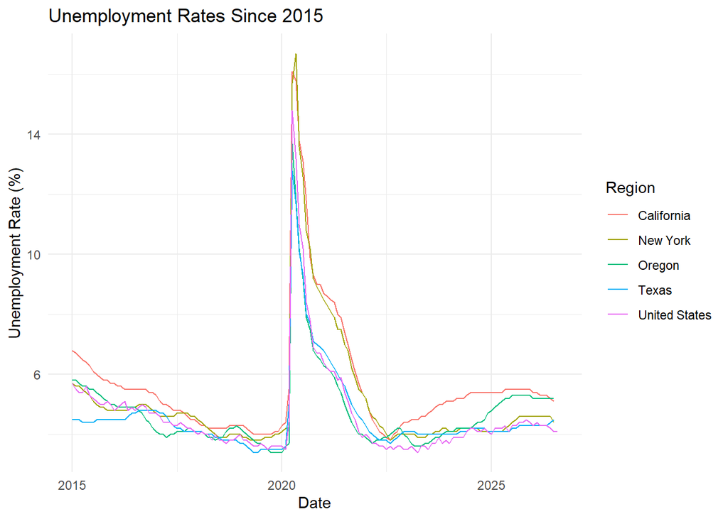

```r
ggplot(unemp_recent,
       aes(x = date, y = unemployment_rate, color = region)) +
  geom_line() +
  labs(
    title = "Unemployment Rates Since 2015",
    x = "Date",
    y = "Unemployment Rate (%)",
    color = "Region"
  ) +
  theme_minimal()
```

I chose to examine unemployment rates since 2015 to focus on recent labor market trends. The chart shows a sharp increase in unemployment during 2020, followed by a decline across all five regions.

## Reflection

In this problem set, reading the saved unemployment data and creating basic plots were relatively straightforward. Cleaning and organizing the data required more attention, especially when dealing with missing values and monthly changes. I also found it challenging to understand how the different R functions work together. Through this assignment, I became more comfortable using pipes and `ggplot2` to analyze and visualize data. I also learned how Git commits help track the progress of my work. Finally, I gained more experience using Quarto to combine code, tables, and explanations in one report.